# Cell2Cell | Variable selection

This analysis uses the shared training split from `01_Data_Cleaning.Rmd` and the predictor eligibility review in `02_EDA.Rmd`. Logistic regression provides an interpretable benchmark for ranking customers when outreach capacity is limited. Predictor selection uses the training partition.

```r
cleaned <- read.csv("Generated_Data/cleaned_data.csv", na.strings = c("", "NA"))
manifest <- read.csv("Generated_Data/split_manifest.csv")
stopifnot(!anyDuplicated(cleaned$CustomerID), !anyDuplicated(manifest$CustomerID),
          setequal(cleaned$CustomerID, manifest$CustomerID))
training_manifest <- subset(manifest, split == "train")
training <- cleaned[match(training_manifest$CustomerID, cleaned$CustomerID), ]
```

The model estimates the chance of the recorded churn outcome, where `Yes` means the customer left during the observation period. A higher score moves an account closer to the top of the outreach list.

## Why tenure enters the model as a curve

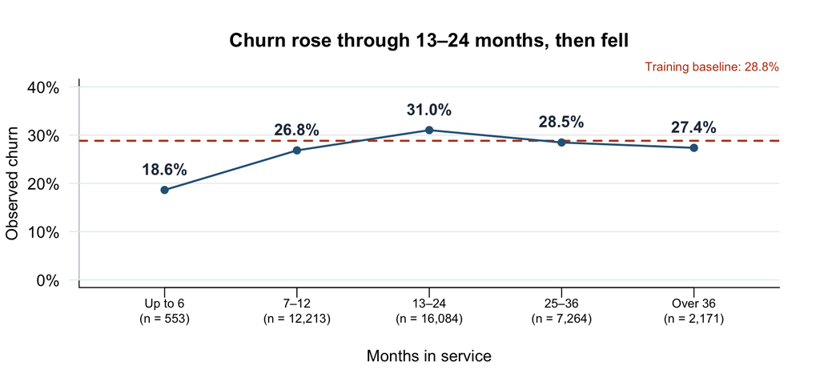

```r
tenure_groups <- cut(
  training$MonthsInService, c(-Inf, 6, 12, 24, 36, Inf),
  labels = c("Up to 6", "7–12", "13–24", "25–36", "Over 36")
)
observed_churn <- training$Churn == "Yes"
tenure_rates <- 100 * tapply(observed_churn, tenure_groups, mean)
tenure_counts <- table(tenure_groups)
positions <- seq_along(tenure_rates)
ticks <- seq(0, 40, 10)

plot(positions, tenure_rates, type = "n", xaxt = "n", yaxt = "n", bty = "l",
     xlim = c(0.55, 5.45), ylim = c(0, 40), xlab = "Months in service",
     ylab = "Observed churn", main = "Churn rose through 13–24 months, then fell")
abline(h = ticks, col = "#E5EBF0")
axis(2, at = ticks, labels = paste0(ticks, "%"), las = 1, col = "#E5EBF0")
axis(1, at = positions, labels = paste0(names(tenure_rates), "\n(n = ",
                                         format(tenure_counts, big.mark = ",", trim = TRUE), ")"),
     cex.axis = 0.77)
abline(h = 100 * mean(observed_churn), col = "#BA4116", lty = 2, lwd = 2)
mtext(sprintf("Training baseline: %.1f%%", 100 * mean(observed_churn)),
      side = 3, line = 0.25, adj = 1, col = "#BA4116", cex = 0.76)
lines(positions, tenure_rates, col = "#2B6387", lwd = 2)
points(positions, tenure_rates, col = "#2B6387", pch = 19)
text(positions, tenure_rates, labels = sprintf("%.1f%%", tenure_rates),
     pos = 3, offset = 0.8, font = 2, col = "#243247")
```

Observed churn rose from **18.6%** in the first six months to **31.0%** at 13–24 months before falling to **27.4%** beyond 36 months. The logistic candidates use a flexible tenure term to represent that change in direction. The chart shows training-group rates. The incremental gain over a linear term remains untested with all other predictors held fixed.

## Feature engineering

The code below defines the derived fields used in exploration and modeling. It computes missingness flags and guarded ratios before any fold imputation.

```r
source("R/preprocessing.R")
feature_groups <- cell2cell_feature_groups()
benchmark <- feature_groups$benchmark
additional_blocks <- feature_groups$additional_blocks
alternate_fields <- feature_groups$alternate_fields
eligible <- c(benchmark, unlist(additional_blocks, use.names = FALSE), alternate_fields)
```

## Feature screening and cross-validation

Add each block separately to the same benchmark to measure its incremental value. Test web capability on its own as well, so its contribution can be read separately from the other handset fields. Also fit a combined model to see how the blocks perform together. These are screening comparisons. Review fold-to-fold consistency before keeping a block. Within each analysis fold, learn numeric medians and spline knots. For categorical fields, use observed analysis-fold levels and replace missing or unseen values with that fold’s most frequent level.

AUC measures how often a churner ranks above a non-churner across the full list. Precision measures the share of selected customers who churned. Lift compares that share with the rate from random selection in the same fold. For example, 10% capacity means reviewing the 100 highest-ranked customers per 1,000. We compare the same 10%, 20%, and 30% cutoffs across models because the best ranking can depend on how many customers the team can contact. A lift of 1.44 means the selected list contained about 44% more historical churners than a random list of the same size.

The first table averages scores across the three validation folds. Changes (`Δ`) are measured against the benchmark on those same folds and cutoffs. The model names match the R formulas used in the handoff.

```r
handoff_predictors <- cell2cell_handoff_predictors()
logistic_terms <- handoff_predictors$logistic
benchmark_terms <- logistic_terms$benchmark
tenure_interaction <- handoff_predictors$tenure_interaction
block_models <- lapply(additional_blocks, function(fields) c(benchmark_terms, fields))
names(block_models) <- paste0("add_", names(block_models))
model_terms <- c(
  list(m1_benchmark = c("MonthsInService", "MonthlyRevenue"),
       benchmark = benchmark_terms),
  block_models,
  list(
    usage_missing = c(benchmark_terms, "UsageChangeMissing"),
    dropped_call_rate = c(benchmark_terms, "MonthlyMinutes", "DroppedCallRate"),
    dropped_rate_reference = c(benchmark_terms, "MonthlyMinutes"),
    inactive_subs = c(benchmark_terms, "InactiveSubs"),
    tenure_equipment = c(benchmark_terms, tenure_interaction),
    web_capability = c(benchmark_terms, "HandsetWebCapable"),
    subscriptions_and_web = logistic_terms$focused,
    all_blocks = logistic_terms$broader_as_screened,
    recurring_charge = c(setdiff(benchmark_terms, "billing_gap"), "TotalRecurringCharge"),
    combined_network = c(setdiff(benchmark_terms, c("DroppedCalls", "BlockedCalls")),
                         "DroppedBlockedCalls")
  )
)
focused_terms <- model_terms$subscriptions_and_web
followup_terms <- list(
  focused_missing = logistic_terms$focused_missing,
  focused_interaction = c(focused_terms, tenure_interaction),
  focused_both = logistic_terms$focused_both,
  focused_active_and_gap = c(setdiff(focused_terms, "UniqueSubs"), "InactiveSubs"),
  focused_gap_only = c(setdiff(focused_terms, c("UniqueSubs", "ActiveSubs")), "InactiveSubs"),
  broader_without_price = logistic_terms$broader_without_price
)
historical_models <- names(model_terms)
model_terms <- c(model_terms, followup_terms)
inputs <- c(eligible, "billing_gap", "UsageChangeMissing", "DroppedCallRate", "InactiveSubs")


training <- add_cell2cell_features(training)
stopifnot(all(training$UsageChangeMissing == is.na(training$PercChangeRevenues)))

fold <- training_manifest$cv_fold
stopifnot(!anyNA(fold), setequal(fold, 1:3))

capacities <- c(0.10, 0.20, 0.30)
validation_results <- lapply(1:3, function(fold_id) {
  analysis <- training[fold != fold_id, ]
  assessment <- training[fold == fold_id, ]
  processed <- prepare_cell2cell_fold(analysis, assessment, inputs)
  analysis <- processed$analysis
  assessment <- processed$assessment

  outcome <- assessment$churn_flag
  positives <- sum(outcome)
  negatives <- length(outcome) - positives

  do.call(rbind, lapply(names(model_terms), function(candidate) {
    fit <- glm(reformulate(model_terms[[candidate]], "churn_flag"),
               family = binomial(), data = analysis, na.action = na.fail)
    stopifnot(fit$converged, nobs(fit) == nrow(analysis),
              identical(rownames(model.frame(fit)), rownames(analysis)),
              all(model.response(model.frame(fit)) == analysis$churn_flag))
    probability <- predict(fit, newdata = assessment, type = "response")
    stopifnot(length(probability) == nrow(assessment), all(is.finite(probability)))
    auc <- (sum(rank(probability)[outcome == 1]) - positives * (positives + 1) / 2) /
      (positives * negatives)
    ranked <- order(-probability, assessment$CustomerID)
    precision <- vapply(capacities, function(capacity) {
      contacted <- head(ranked, floor(capacity * length(ranked)))
      mean(outcome[contacted])
    }, numeric(1))

    data.frame(fold = fold_id, model = candidate, capacity = capacities, auc = auc,
               precision = precision, lift = precision / mean(outcome), bic = BIC(fit))
  }))
})

fold_scores <- do.call(rbind, validation_results)
benchmark_scores <- subset(fold_scores, model == "benchmark",
                           select = c(fold, capacity, auc, lift))
names(benchmark_scores)[3:4] <- c("benchmark_auc", "benchmark_lift")
paired <- merge(fold_scores, benchmark_scores, by = c("fold", "capacity"))
paired$auc_change <- paired$auc - paired$benchmark_auc
paired$lift_change <- paired$lift - paired$benchmark_lift
selection_summary <- aggregate(cbind(auc, precision, lift, auc_change, lift_change) ~
                                 model + capacity, paired, mean)
display_scores <- subset(selection_summary, model %in% historical_models)
display_scores$capacity <- paste0(100 * display_scores$capacity, "%")
display_scores$precision <- sprintf("%.1f%%", 100 * display_scores$precision)
knitr::kable(display_scores, digits = 3,
             col.names = c("Model", "Outreach capacity", "AUC", "Precision", "Lift",
                           "Δ AUC", "Δ lift"),
             caption = "Average performance on the shared validation folds")
```

Average performance on the shared validation folds

|  | Model | Outreach capacity | AUC | Precision | Lift | Δ AUC | Δ lift |
| --- | --- | --- | --- | --- | --- | --- | --- |
| 1 | add_account_history | 10% | 0.606 | 39.3% | 1.365 | 0.000 | 0.001 |
| 2 | add_calling | 10% | 0.608 | 39.9% | 1.384 | 0.003 | 0.020 |
| 3 | add_handset | 10% | 0.610 | 40.2% | 1.395 | 0.005 | 0.031 |
| 4 | add_overage | 10% | 0.605 | 39.3% | 1.362 | 0.000 | -0.002 |
| 5 | add_roaming | 10% | 0.606 | 39.4% | 1.367 | 0.000 | 0.003 |
| 6 | add_subscriptions | 10% | 0.610 | 40.9% | 1.420 | 0.004 | 0.055 |
| 7 | all_blocks | 10% | 0.617 | 40.9% | 1.420 | 0.011 | 0.055 |
| 8 | benchmark | 10% | 0.605 | 39.3% | 1.364 | 0.000 | 0.000 |
| 10 | combined_network | 10% | 0.605 | 38.8% | 1.347 | 0.000 | -0.017 |
| 11 | dropped_call_rate | 10% | 0.610 | 40.3% | 1.400 | 0.004 | 0.035 |
| 12 | dropped_rate_reference | 10% | 0.608 | 39.6% | 1.373 | 0.003 | 0.009 |
| 18 | inactive_subs | 10% | 0.610 | 41.2% | 1.429 | 0.005 | 0.064 |
| 19 | m1_benchmark | 10% | 0.521 | 29.2% | 1.012 | -0.085 | -0.353 |
| 20 | recurring_charge | 10% | 0.605 | 39.3% | 1.363 | 0.000 | -0.001 |
| 21 | subscriptions_and_web | 10% | 0.612 | 41.4% | 1.435 | 0.006 | 0.071 |
| 22 | tenure_equipment | 10% | 0.609 | 41.1% | 1.427 | 0.004 | 0.063 |
| 23 | usage_missing | 10% | 0.608 | 40.7% | 1.412 | 0.002 | 0.048 |
| 24 | web_capability | 10% | 0.608 | 40.4% | 1.401 | 0.003 | 0.036 |
| 25 | add_account_history | 20% | 0.606 | 36.3% | 1.261 | 0.000 | -0.009 |
| 26 | add_calling | 20% | 0.608 | 37.1% | 1.289 | 0.003 | 0.019 |
| 27 | add_handset | 20% | 0.610 | 38.3% | 1.328 | 0.005 | 0.058 |
| 28 | add_overage | 20% | 0.605 | 36.5% | 1.268 | 0.000 | -0.002 |
| 29 | add_roaming | 20% | 0.606 | 36.6% | 1.269 | 0.000 | 0.000 |
| 30 | add_subscriptions | 20% | 0.610 | 37.6% | 1.304 | 0.004 | 0.035 |
| 31 | all_blocks | 20% | 0.617 | 38.9% | 1.348 | 0.011 | 0.079 |
| 32 | benchmark | 20% | 0.605 | 36.6% | 1.270 | 0.000 | 0.000 |
| 34 | combined_network | 20% | 0.605 | 36.5% | 1.268 | 0.000 | -0.002 |
| 35 | dropped_call_rate | 20% | 0.610 | 37.9% | 1.314 | 0.004 | 0.044 |
| 36 | dropped_rate_reference | 20% | 0.608 | 37.2% | 1.292 | 0.003 | 0.023 |
| 42 | inactive_subs | 20% | 0.610 | 37.7% | 1.307 | 0.005 | 0.037 |
| 43 | m1_benchmark | 20% | 0.521 | 29.9% | 1.039 | -0.085 | -0.231 |
| 44 | recurring_charge | 20% | 0.605 | 36.6% | 1.270 | 0.000 | 0.000 |
| 45 | subscriptions_and_web | 20% | 0.612 | 38.2% | 1.327 | 0.006 | 0.058 |
| 46 | tenure_equipment | 20% | 0.609 | 38.4% | 1.333 | 0.004 | 0.063 |
| 47 | usage_missing | 20% | 0.608 | 36.9% | 1.281 | 0.002 | 0.012 |
| 48 | web_capability | 20% | 0.608 | 37.8% | 1.311 | 0.003 | 0.041 |
| 49 | add_account_history | 30% | 0.606 | 35.7% | 1.238 | 0.000 | -0.010 |
| 50 | add_calling | 30% | 0.608 | 36.4% | 1.264 | 0.003 | 0.016 |
| 51 | add_handset | 30% | 0.610 | 36.5% | 1.268 | 0.005 | 0.020 |
| 52 | add_overage | 30% | 0.605 | 36.0% | 1.248 | 0.000 | 0.000 |
| 53 | add_roaming | 30% | 0.606 | 35.9% | 1.247 | 0.000 | -0.001 |
| 54 | add_subscriptions | 30% | 0.610 | 36.3% | 1.259 | 0.004 | 0.011 |
| 55 | all_blocks | 30% | 0.617 | 37.6% | 1.306 | 0.011 | 0.058 |
| 56 | benchmark | 30% | 0.605 | 36.0% | 1.248 | 0.000 | 0.000 |
| 58 | combined_network | 30% | 0.605 | 36.0% | 1.249 | 0.000 | 0.002 |
| 59 | dropped_call_rate | 30% | 0.610 | 36.7% | 1.272 | 0.004 | 0.024 |
| 60 | dropped_rate_reference | 30% | 0.608 | 36.3% | 1.259 | 0.003 | 0.011 |
| 66 | inactive_subs | 30% | 0.610 | 36.4% | 1.263 | 0.005 | 0.015 |
| 67 | m1_benchmark | 30% | 0.521 | 29.6% | 1.027 | -0.085 | -0.221 |
| 68 | recurring_charge | 30% | 0.605 | 36.0% | 1.248 | 0.000 | 0.000 |
| 69 | subscriptions_and_web | 30% | 0.612 | 36.7% | 1.272 | 0.006 | 0.024 |
| 70 | tenure_equipment | 30% | 0.609 | 36.8% | 1.277 | 0.004 | 0.029 |
| 71 | usage_missing | 30% | 0.608 | 36.3% | 1.259 | 0.002 | 0.011 |
| 72 | web_capability | 30% | 0.608 | 36.1% | 1.254 | 0.003 | 0.006 |

### Which features improved the top 10% list?

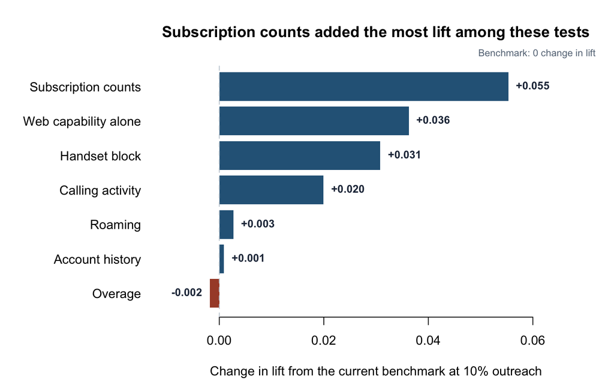

```r
block_labels <- c(
  add_subscriptions = "Subscription counts", web_capability = "Web capability alone",
  add_handset = "Handset block", add_calling = "Calling activity",
  add_roaming = "Roaming", add_account_history = "Account history",
  add_overage = "Overage"
)
block_scores <- subset(selection_summary, capacity == 0.10 & model %in% names(block_labels))
block_scores <- block_scores[order(block_scores$lift_change), ]
block_labels_ordered <- unname(block_labels[block_scores$model])
old_par <- par(mar = c(4.3, 10.2, 4.1, 1.2))
positions <- barplot(
  block_scores$lift_change, names.arg = block_labels_ordered, horiz = TRUE,
  xlim = c(-0.012, 0.072), las = 1, border = NA,
  col = ifelse(block_scores$lift_change < 0, "#A84C35", "#2B6387"),
  main = "Subscription counts added the most lift among these tests",
  xlab = "Change in lift from the current benchmark at 10% outreach"
)
abline(v = 0, col = "#BFCAD3", lty = 2)
mtext("Benchmark: 0 change in lift", side = 3, line = 0.25,
      adj = 1, col = "#697888", cex = 0.76)
text(block_scores$lift_change, positions,
     labels = sprintf("%+.3f", block_scores$lift_change),
     pos = ifelse(block_scores$lift_change < 0, 2, 4),
     font = 2, col = "#243247", cex = 0.85)
```

```r
par(old_par)
```

Each addition was tested against the same benchmark. Subscription counts and web capability gave the clearest gains among the features shown, while roaming and overage changed lift very little. The block results describe the predictors tested together.

### How the shortlist changes with outreach capacity

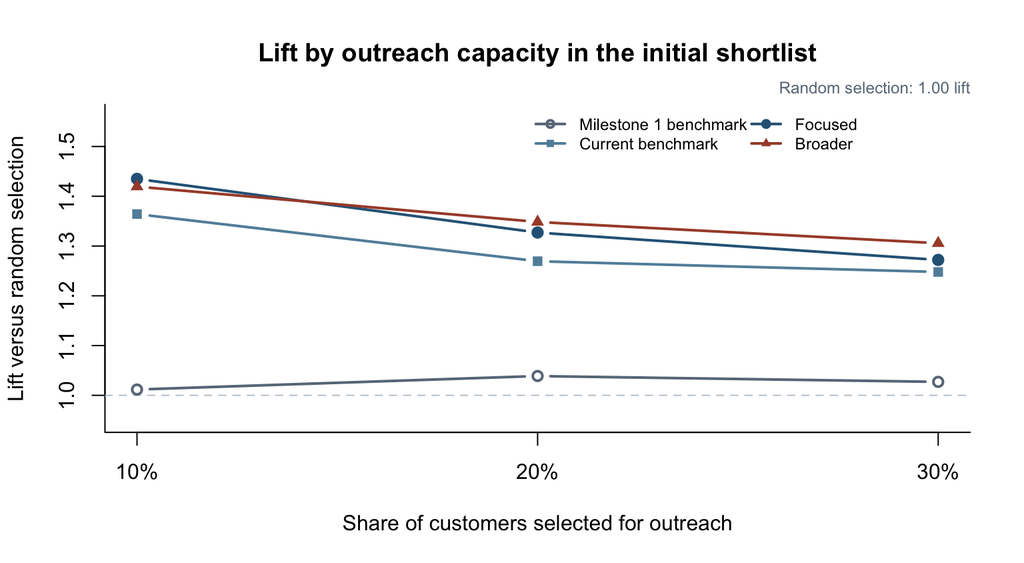

```r
shortlist <- c("m1_benchmark", "benchmark", "subscriptions_and_web", "all_blocks")
shortlist_labels <- c("Milestone 1 benchmark", "Current benchmark", "Focused", "Broader")
shortlist_colors <- c("#697888", "#628FA9", "#2B6387", "#A84C35")
shortlist_symbols <- c(1, 15, 19, 17)
lift_lines <- vapply(shortlist, function(candidate) {
  scores <- subset(selection_summary, model == candidate)
  scores$lift[match(capacities, scores$capacity)]
}, numeric(length(capacities)))

plot(100 * capacities, lift_lines[, 1], type = "n", ylim = c(0.95, 1.56),
     xaxt = "n", bty = "l", xlab = "Share of customers selected for outreach",
     ylab = "Lift versus random selection",
     main = "Lift by outreach capacity in the initial shortlist")
axis(1, at = 100 * capacities, labels = paste0(100 * capacities, "%"))
abline(h = 1, col = "#BFCAD3", lty = 2)
mtext("Random selection: 1.00 lift", side = 3, line = 0.25,
      adj = 1, col = "#697888", cex = 0.76)
matlines(100 * capacities, lift_lines, type = "b", lty = 1,
         pch = shortlist_symbols, col = shortlist_colors, lwd = 2)
legend("topright", legend = shortlist_labels, col = shortlist_colors,
       pch = shortlist_symbols, lty = 1, lwd = 2, ncol = 2, bty = "n", cex = 0.76)
```

In the initial screen, the focused candidate led at 10% outreach and the broader candidate led at 20% and 30% among the four models shown. Lift of 1 means a list caught the same share of historical churners as random selection at that capacity.

The fold-by-fold results show whether gains at 10% outreach are consistent across different groups of customers.

### Fold-by-fold results at 10% outreach

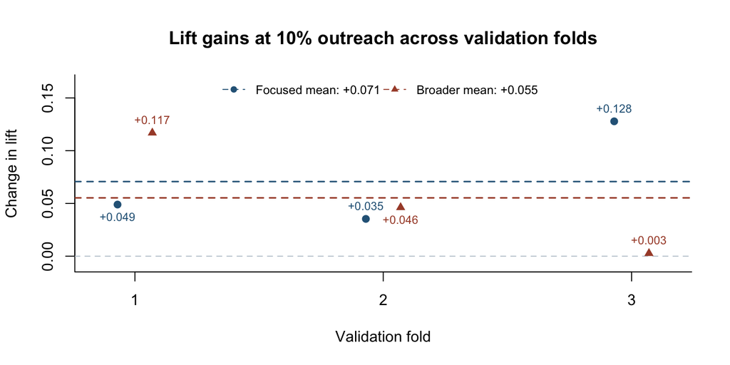

```r
fold_ids <- sort(unique(paired$fold))
contender_ids <- c("subscriptions_and_web", "all_blocks")
fold_deltas <- vapply(contender_ids, function(candidate) {
  scores <- subset(paired, capacity == 0.10 & model == candidate)
  scores$lift_change[match(fold_ids, scores$fold)]
}, numeric(length(fold_ids)))
mean_fold_deltas <- colMeans(fold_deltas)
fold_limits <- range(pretty(range(0, fold_deltas))) + c(-0.008, 0.025)
plot(fold_ids, fold_deltas[, 1], type = "n", ylim = fold_limits,
     xlim = range(fold_ids) + c(-0.15, 0.15), xaxt = "n", bty = "l",
     xlab = "Validation fold", ylab = "Change in lift",
     main = "Lift gains at 10% outreach across validation folds")
axis(1, at = fold_ids)
abline(h = 0, lty = 2, col = "#BFCAD3")
abline(h = mean_fold_deltas, lty = 2, lwd = 1.6, col = c("#2B6387", "#A84C35"))
points(fold_ids - 0.07, fold_deltas[, 1], pch = 19, col = "#2B6387")
points(fold_ids + 0.07, fold_deltas[, 2], pch = 17, col = "#A84C35")
fold_label_side <- function(values) {
  distance_above <- outer(mean_fold_deltas, values, "-")
  ifelse(colSums(distance_above > 0 & distance_above < 0.018) > 0, 1, 3)
}
text(fold_ids - 0.07, fold_deltas[, 1], labels = sprintf("%+.3f", fold_deltas[, 1]),
     pos = fold_label_side(fold_deltas[, 1]), cex = 0.76, col = "#2B6387")
text(fold_ids + 0.07, fold_deltas[, 2], labels = sprintf("%+.3f", fold_deltas[, 2]),
     pos = fold_label_side(fold_deltas[, 2]), cex = 0.76, col = "#A84C35")
legend("top", legend = sprintf("%s mean: %+.3f", c("Focused", "Broader"), mean_fold_deltas),
       pch = c(19, 17), lty = 2, col = c("#2B6387", "#A84C35"),
       horiz = TRUE, bty = "n", cex = 0.8)
```

The focused model improved lift over the benchmark in **3 of 3 folds**. The broader model improved it in **3 of 3 folds**. The dots show individual fold results, the colored dashed lines show each model’s mean lift gain, and the gray line marks zero change.

```r
fold_display <- subset(
  paired,
  capacity == 0.10 & model %in% historical_models,
  select = c(fold, model, auc_change, lift_change)
)
knitr::kable(
  fold_display,
  digits = 3,
  col.names = c("Validation fold", "Model", "Δ AUC", "Δ lift")
)
```

|  | Validation fold | Model | Δ AUC | Δ lift |
| --- | --- | --- | --- | --- |
| 1 | 1 | m1_benchmark | -0.084 | -0.296 |
| 3 | 1 | subscriptions_and_web | 0.007 | 0.049 |
| 4 | 1 | benchmark | 0.000 | 0.000 |
| 6 | 1 | all_blocks | 0.016 | 0.117 |
| 7 | 1 | add_handset | 0.009 | 0.082 |
| 9 | 1 | recurring_charge | 0.000 | -0.003 |
| 10 | 1 | add_roaming | 0.000 | 0.003 |
| 12 | 1 | combined_network | 0.000 | -0.019 |
| 13 | 1 | add_overage | 0.000 | 0.000 |
| 15 | 1 | dropped_call_rate | 0.003 | 0.052 |
| 16 | 1 | add_subscriptions | 0.005 | 0.063 |
| 18 | 1 | dropped_rate_reference | 0.002 | 0.038 |
| 19 | 1 | add_account_history | 0.000 | -0.014 |
| 20 | 1 | tenure_equipment | 0.005 | 0.103 |
| 21 | 1 | inactive_subs | 0.005 | 0.068 |
| 22 | 1 | add_calling | 0.003 | 0.052 |
| 23 | 1 | web_capability | 0.002 | 0.038 |
| 24 | 1 | usage_missing | 0.002 | 0.065 |
| 73 | 2 | m1_benchmark | -0.085 | -0.375 |
| 75 | 2 | subscriptions_and_web | 0.005 | 0.035 |
| 76 | 2 | benchmark | 0.000 | 0.000 |
| 78 | 2 | all_blocks | 0.009 | 0.046 |
| 79 | 2 | add_handset | 0.004 | 0.054 |
| 81 | 2 | recurring_charge | 0.000 | 0.000 |
| 82 | 2 | add_roaming | 0.000 | 0.000 |
| 84 | 2 | combined_network | 0.000 | -0.011 |
| 85 | 2 | add_overage | 0.000 | 0.000 |
| 87 | 2 | dropped_call_rate | 0.005 | 0.027 |
| 88 | 2 | add_subscriptions | 0.002 | 0.008 |
| 90 | 2 | dropped_rate_reference | 0.003 | 0.003 |
| 91 | 2 | add_account_history | 0.000 | 0.011 |
| 92 | 2 | tenure_equipment | 0.003 | 0.041 |
| 93 | 2 | inactive_subs | 0.003 | 0.035 |
| 94 | 2 | add_calling | 0.003 | -0.003 |
| 95 | 2 | web_capability | 0.003 | 0.046 |
| 96 | 2 | usage_missing | 0.002 | 0.046 |
| 145 | 3 | m1_benchmark | -0.085 | -0.386 |
| 147 | 3 | subscriptions_and_web | 0.008 | 0.128 |
| 148 | 3 | benchmark | 0.000 | 0.000 |
| 150 | 3 | all_blocks | 0.009 | 0.003 |
| 151 | 3 | add_handset | 0.001 | -0.044 |
| 153 | 3 | recurring_charge | 0.000 | 0.000 |
| 154 | 3 | add_roaming | 0.000 | 0.005 |
| 156 | 3 | combined_network | 0.000 | -0.022 |
| 157 | 3 | add_overage | 0.000 | -0.005 |
| 159 | 3 | dropped_call_rate | 0.005 | 0.027 |
| 160 | 3 | add_subscriptions | 0.006 | 0.095 |
| 162 | 3 | dropped_rate_reference | 0.003 | -0.014 |
| 163 | 3 | add_account_history | 0.000 | 0.005 |
| 164 | 3 | tenure_equipment | 0.004 | 0.044 |
| 165 | 3 | inactive_subs | 0.006 | 0.090 |
| 166 | 3 | add_calling | 0.002 | 0.011 |
| 167 | 3 | web_capability | 0.003 | 0.024 |
| 168 | 3 | usage_missing | 0.003 | 0.033 |

## Secondary check using BIC

BIC uses fit and the number of estimated parameters to compare logistic candidates. Each comparison uses the same fitting rows and outcome within a fold. Lower values favor fit relative to complexity. Average differences from the benchmark describe the three folds. Outreach lift and business relevance take priority when these comparisons point in different directions.

### Billing terms and multicollinearity

The logistic candidates use either `MonthlyRevenue` and `billing_gap`, or `MonthlyRevenue` and `TotalRecurringCharge` as linear terms. When all billing values are observed, the two versions contain the same information because `MonthlyRevenue = TotalRecurringCharge + billing_gap`.

Including all three terms would create **perfect multicollinearity** on complete records. Any one of the three can be calculated from the other two, so the model cannot uniquely estimate a separate coefficient for each. R may drop a redundant term when fitting the model. Filling missing values separately can break the exact identity for some records, but the terms still carry overlapping information and their coefficients can be unstable.

```r
bic_comparison <- unique(paired[c("fold", "model", "bic")])
benchmark_bic <- subset(bic_comparison, model == "benchmark")
bic_comparison$bic_change <- bic_comparison$bic -
  benchmark_bic$bic[match(bic_comparison$fold, benchmark_bic$fold)]
bic_summary <- aggregate(bic_change ~ model, bic_comparison, mean)
knitr::kable(subset(bic_summary, model %in% historical_models), digits = 1,
             col.names = c("Model", "Mean difference from benchmark BIC"))
```

|  | Model | Mean difference from benchmark BIC |
| --- | --- | --- |
| 1 | add_account_history | 23.1 |
| 2 | add_calling | 74.8 |
| 3 | add_handset | -34.9 |
| 4 | add_overage | 10.0 |
| 5 | add_roaming | 8.6 |
| 6 | add_subscriptions | -52.0 |
| 7 | all_blocks | 28.6 |
| 8 | benchmark | 0.0 |
| 10 | combined_network | -8.6 |
| 11 | dropped_call_rate | -13.1 |
| 12 | dropped_rate_reference | -9.3 |
| 18 | inactive_subs | -60.7 |
| 19 | m1_benchmark | 642.4 |
| 20 | recurring_charge | -0.2 |
| 21 | subscriptions_and_web | -63.0 |
| 22 | tenure_equipment | -23.5 |
| 23 | usage_missing | -38.6 |
| 24 | web_capability | -13.4 |

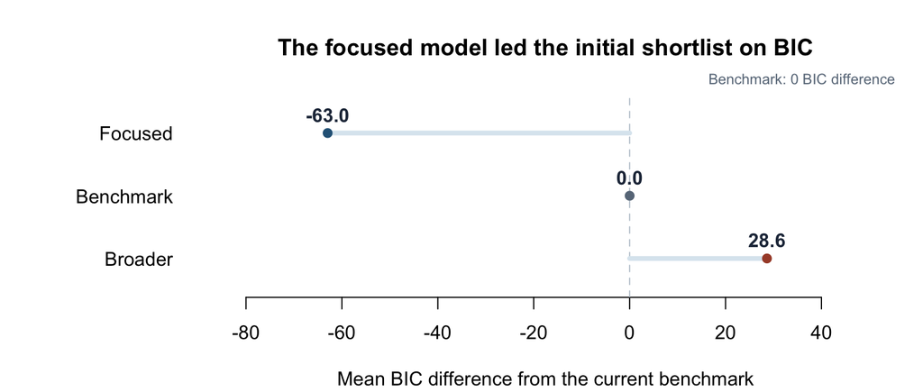

```r
bic_candidates <- c("all_blocks", "benchmark", "subscriptions_and_web")
bic_changes <- bic_summary$bic_change[match(bic_candidates, bic_summary$model)]
old_par <- par(mar = c(4.1, 8.5, 4.1, 1.2))
plot(bic_changes, 1:3, type = "n", axes = FALSE, bty = "n",
     xlim = c(-85, 50), ylim = c(0.5, 3.5),
     xlab = "Mean BIC difference from the current benchmark",
     ylab = "", main = "The focused model led the initial shortlist on BIC")
axis(1)
axis(2, at = 1:3, labels = c("Broader", "Benchmark", "Focused"),
     las = 1, tick = FALSE)
abline(v = 0, lty = 2, col = "#BFCAD3")
mtext("Benchmark: 0 BIC difference", side = 3, line = 0.25,
      adj = 1, col = "#697888", cex = 0.76)
segments(0, 1:3, bic_changes, 1:3, lwd = 4, col = "#DCE8F0")
points(bic_changes, 1:3, pch = 19, col = c("#A84C35", "#697888", "#2B6387"))
text(bic_changes, 1:3, labels = sprintf("%.1f", bic_changes), pos = 3,
     font = 2, col = "#243247")
```

```r
par(old_par)
```

### What this means

In the initial screen, the focused candidate had the lowest mean BIC, 63.0 points below the benchmark. The broader model was 28.6 points above the benchmark despite achieving higher overall AUC.

## What the tenure-by-equipment interaction added

Both models use the same predictors and training folds. The second adds the interaction so the relationship between equipment age and churn can vary with tenure.

```r
interaction_models <- c("benchmark", "tenure_equipment")
interaction_metrics <- vapply(interaction_models, function(candidate) {
  scores <- subset(selection_summary, model == candidate)
  scores <- scores[match(capacities, scores$capacity), ]
  bic_delta <- bic_summary$bic_change[match(candidate, bic_summary$model)]
  c(sprintf("%.3f", scores$auc[1]),
    sprintf("%.1f%%", 100 * scores$precision[1]),
    sprintf("%.3f", scores$lift),
    sprintf("%.1f", bic_delta))
}, character(6))
knitr::kable(
  data.frame(
    Metric = c("AUC", "Top 10% precision", "Top 10% lift", "Top 20% lift",
               "Top 30% lift", "Mean BIC difference from benchmark"),
    Benchmark = interaction_metrics[, "benchmark"],
    `With interaction` = interaction_metrics[, "tenure_equipment"],
    check.names = FALSE
  ),
  align = c("l", "r", "r"),
  caption = "Comparison on the three shared training folds"
)
```

Comparison on the three shared training folds

| Metric | Benchmark | With interaction |
| --- | --- | --- |
| AUC | 0.605 | 0.609 |
| Top 10% precision | 39.3% | 41.1% |
| Top 10% lift | 1.364 | 1.427 |
| Top 20% lift | 1.270 | 1.333 |
| Top 30% lift | 1.248 | 1.277 |
| Mean BIC difference from benchmark | 0.0 | -23.5 |

The interaction improved each metric shown. At 10% outreach, precision rose from **39.3% to 41.1%**, or about two more historical churners per 100 customers selected. BIC fell by **23.5 points**, suggesting that the improvement in fit justified the extra terms by that criterion. That benchmark comparison motivated the focused-model test below.

## Follow-up comparisons on the focused and broader models

The focused reference has 12 formula terms. Each change below uses the same training rows and fold-level preprocessing as its reference. The analysis checks convergence, matching fitting rows and outcomes, and finite validation predictions for every candidate. The usage and revenue changes are missing on exactly the same training records, so `UsageChangeMissing` represents both here and is calculated before imputation.

| Comparison | Exact change and what it tests |
| --- | --- |
| Focused + missingness | Add `UsageChangeMissing` to test whether an unavailable change adds ranking information beyond the recorded usage and revenue changes. |
| Focused + interaction | Add the spline-tenure × equipment-age interaction and keep both main effects. This tests whether an older handset changes relative ranking differently at different tenure levels. |
| Focused + both | Add both terms to see whether missingness and the interaction together improve the outreach list. |
| Focused with active lines and subscription gap | Replace `UniqueSubs` with `InactiveSubs` and keep `ActiveSubs`. On these complete subscription counts this is the same linear information. This comparison verifies equivalence. |
| Focused with subscription gap only | Replace both subscription counts with `InactiveSubs`. This tests whether the gap alone can support a simpler outreach ranking. |
| Broader without handset price | Remove `HandsetPrice` and keep every other broader term. This tests whether the heavily imputed price field helps the list when the other device fields are available. |

```r
comparison_labels <- c(
  focused_missing = "Focused + missingness",
  focused_interaction = "Focused + interaction",
  focused_both = "Focused + both",
  focused_active_and_gap = "Focused: active lines + gap",
  focused_gap_only = "Focused: gap only",
  broader_without_price = "Broader without handset price"
)
followup <- do.call(rbind, lapply(names(followup_terms), function(candidate) {
  reference <- if (candidate == "broader_without_price") "all_blocks" else "subscriptions_and_web"
  scores <- subset(fold_scores, model == candidate)
  ref <- subset(fold_scores, model == reference)
  ref <- ref[match(paste(scores$fold, scores$capacity), paste(ref$fold, ref$capacity)), ]
  stopifnot(!anyNA(ref$fold), all(scores$fold == ref$fold),
            all(scores$capacity == ref$capacity))
  data.frame(
    comparison = comparison_labels[[candidate]], fold = scores$fold,
    capacity = scores$capacity, auc = scores$auc,
    precision = scores$precision, lift = scores$lift,
    auc_delta = scores$auc - ref$auc,
    precision_delta = scores$precision - ref$precision,
    lift_delta = scores$lift - ref$lift,
    bic_delta = scores$bic - ref$bic
  )
}))
followup_means <- aggregate(
  cbind(auc, precision, lift, auc_delta, precision_delta, lift_delta, bic_delta) ~
    comparison + capacity, data = followup, FUN = mean
)

format_followup <- function(scores) {
  scores$capacity <- sprintf("%.0f%%", 100 * scores$capacity)
  scores$precision <- sprintf("%.1f%%", 100 * scores$precision)
  scores$precision_delta <- sprintf("%+.2f", 100 * scores$precision_delta)
  scores$bic_delta <- ifelse(scores$capacity == "10%", sprintf("%+.1f", scores$bic_delta), "")
  scores
}
score_labels <- c("Outreach", "AUC", "Precision", "Lift", "AUC change",
                  "Precision change (percentage points)", "Lift change", "BIC change")
knitr::kable(
  format_followup(followup_means[order(match(followup_means$comparison, comparison_labels),
                                     followup_means$capacity), ]),
  col.names = c("Comparison", score_labels), digits = 3, row.names = FALSE,
  caption = "Mean training-fold scores and paired changes versus each reference"
)
```

Mean training-fold scores and paired changes versus each reference

| Comparison | Outreach | AUC | Precision | Lift | AUC change | Precision change (percentage points) | Lift change | BIC change |
| --- | --- | --- | --- | --- | --- | --- | --- | --- |
| Focused + missingness | 10% | 0.614 | 42.3% | 1.467 | 0.002 | +0.91 | 0.032 | -37.4 |
| Focused + missingness | 20% | 0.614 | 38.7% | 1.342 | 0.002 | +0.43 | 0.015 |  |
| Focused + missingness | 30% | 0.614 | 36.9% | 1.281 | 0.002 | +0.24 | 0.008 |  |
| Focused + interaction | 10% | 0.615 | 41.6% | 1.444 | 0.003 | +0.26 | 0.009 | -21.7 |
| Focused + interaction | 20% | 0.615 | 39.2% | 1.359 | 0.003 | +0.91 | 0.032 |  |
| Focused + interaction | 30% | 0.615 | 37.6% | 1.305 | 0.003 | +0.96 | 0.033 |  |
| Focused + both | 10% | 0.617 | 43.1% | 1.495 | 0.005 | +1.72 | 0.060 | -65.4 |
| Focused + both | 20% | 0.617 | 39.6% | 1.375 | 0.005 | +1.38 | 0.048 |  |
| Focused + both | 30% | 0.617 | 37.8% | 1.311 | 0.005 | +1.11 | 0.039 |  |
| Focused: active lines + gap | 10% | 0.612 | 41.4% | 1.435 | 0.000 | +0.00 | 0.000 | +0.0 |
| Focused: active lines + gap | 20% | 0.612 | 38.2% | 1.327 | 0.000 | +0.00 | 0.000 |  |
| Focused: active lines + gap | 30% | 0.612 | 36.7% | 1.272 | 0.000 | +0.00 | 0.000 |  |
| Focused: gap only | 10% | 0.612 | 41.5% | 1.441 | 0.000 | +0.18 | 0.006 | -8.7 |
| Focused: gap only | 20% | 0.612 | 38.5% | 1.335 | 0.000 | +0.22 | 0.008 |  |
| Focused: gap only | 30% | 0.612 | 36.6% | 1.270 | 0.000 | -0.07 | -0.002 |  |
| Broader without handset price | 10% | 0.617 | 40.9% | 1.420 | 0.000 | +0.03 | 0.001 | -9.1 |
| Broader without handset price | 20% | 0.617 | 38.8% | 1.347 | 0.000 | -0.04 | -0.001 |  |
| Broader without handset price | 30% | 0.617 | 37.5% | 1.300 | 0.000 | -0.17 | -0.006 |  |

The BIC change is listed once per comparison because outreach capacity does not change the fitted model. A negative BIC change favors the candidate on fit adjusted for the number of parameters.

### Results across individual folds

```r
fold_order <- order(match(followup$comparison, comparison_labels),
                    followup$fold, followup$capacity)
knitr::kable(
  format_followup(followup[fold_order, ]), digits = 3, row.names = FALSE,
  col.names = c("Comparison", "Fold", score_labels),
  caption = "Fold-level scores and changes on identical assessment customers"
)
```

Fold-level scores and changes on identical assessment customers

| Comparison | Fold | Outreach | AUC | Precision | Lift | AUC change | Precision change (percentage points) | Lift change | BIC change |
| --- | --- | --- | --- | --- | --- | --- | --- | --- | --- |
| Focused + missingness | 1 | 10% | 0.610 | 39.8% | 1.381 | 0.002 | +0.71 | 0.024 | -34.6 |
| Focused + missingness | 1 | 20% | 0.610 | 37.9% | 1.316 | 0.002 | +0.39 | 0.014 |  |
| Focused + missingness | 1 | 30% | 0.610 | 36.5% | 1.266 | 0.002 | +0.10 | 0.004 |  |
| Focused + missingness | 2 | 10% | 0.611 | 42.5% | 1.474 | 0.002 | +1.57 | 0.054 | -41.3 |
| Focused + missingness | 2 | 20% | 0.611 | 38.6% | 1.339 | 0.002 | +0.24 | 0.008 |  |
| Focused + missingness | 2 | 30% | 0.611 | 37.0% | 1.283 | 0.002 | +0.31 | 0.011 |  |
| Focused + missingness | 3 | 10% | 0.621 | 44.5% | 1.545 | 0.003 | +0.47 | 0.016 | -36.3 |
| Focused + missingness | 3 | 20% | 0.621 | 39.5% | 1.371 | 0.003 | +0.67 | 0.023 |  |
| Focused + missingness | 3 | 30% | 0.621 | 37.3% | 1.293 | 0.003 | +0.31 | 0.011 |  |
| Focused + interaction | 1 | 10% | 0.611 | 40.9% | 1.419 | 0.003 | +1.80 | 0.063 | -24.5 |
| Focused + interaction | 1 | 20% | 0.611 | 38.0% | 1.319 | 0.003 | +0.47 | 0.016 |  |
| Focused + interaction | 1 | 30% | 0.611 | 37.6% | 1.304 | 0.003 | +1.20 | 0.042 |  |
| Focused + interaction | 2 | 10% | 0.612 | 41.2% | 1.430 | 0.003 | +0.31 | 0.011 | -25.4 |
| Focused + interaction | 2 | 20% | 0.612 | 39.3% | 1.364 | 0.003 | +0.94 | 0.033 |  |
| Focused + interaction | 2 | 30% | 0.612 | 37.3% | 1.295 | 0.003 | +0.68 | 0.024 |  |
| Focused + interaction | 3 | 10% | 0.622 | 42.7% | 1.482 | 0.004 | -1.33 | -0.046 | -15.1 |
| Focused + interaction | 3 | 20% | 0.622 | 40.2% | 1.394 | 0.004 | +1.33 | 0.046 |  |
| Focused + interaction | 3 | 30% | 0.622 | 37.9% | 1.316 | 0.004 | +0.99 | 0.034 |  |
| Focused + both | 1 | 10% | 0.613 | 42.4% | 1.471 | 0.005 | +3.29 | 0.114 | -68.0 |
| Focused + both | 1 | 20% | 0.613 | 38.4% | 1.334 | 0.005 | +0.90 | 0.031 |  |
| Focused + both | 1 | 30% | 0.613 | 37.6% | 1.306 | 0.005 | +1.25 | 0.044 |  |
| Focused + both | 2 | 10% | 0.614 | 42.2% | 1.466 | 0.005 | +1.33 | 0.046 | -71.9 |
| Focused + both | 2 | 20% | 0.614 | 39.6% | 1.373 | 0.005 | +1.21 | 0.042 |  |
| Focused + both | 2 | 30% | 0.614 | 37.6% | 1.305 | 0.005 | +0.97 | 0.034 |  |
| Focused + both | 3 | 10% | 0.625 | 44.6% | 1.548 | 0.007 | +0.55 | 0.019 | -56.3 |
| Focused + both | 3 | 20% | 0.625 | 40.9% | 1.418 | 0.007 | +2.04 | 0.071 |  |
| Focused + both | 3 | 30% | 0.625 | 38.1% | 1.321 | 0.007 | +1.12 | 0.039 |  |
| Focused: active lines + gap | 1 | 10% | 0.608 | 39.1% | 1.357 | 0.000 | +0.00 | 0.000 | +0.0 |
| Focused: active lines + gap | 1 | 20% | 0.608 | 37.5% | 1.303 | 0.000 | +0.00 | 0.000 |  |
| Focused: active lines + gap | 1 | 30% | 0.608 | 36.4% | 1.263 | 0.000 | +0.00 | 0.000 |  |
| Focused: active lines + gap | 2 | 10% | 0.609 | 40.9% | 1.419 | 0.000 | +0.00 | 0.000 | +0.0 |
| Focused: active lines + gap | 2 | 20% | 0.609 | 38.4% | 1.331 | 0.000 | +0.00 | 0.000 |  |
| Focused: active lines + gap | 2 | 30% | 0.609 | 36.7% | 1.272 | 0.000 | +0.00 | 0.000 |  |
| Focused: active lines + gap | 3 | 10% | 0.618 | 44.0% | 1.529 | 0.000 | +0.00 | 0.000 | +0.0 |
| Focused: active lines + gap | 3 | 20% | 0.618 | 38.8% | 1.348 | 0.000 | +0.00 | 0.000 |  |
| Focused: active lines + gap | 3 | 30% | 0.618 | 36.9% | 1.282 | 0.000 | +0.00 | 0.000 |  |
| Focused: gap only | 1 | 10% | 0.608 | 38.9% | 1.349 | 0.000 | -0.24 | -0.008 | -9.9 |
| Focused: gap only | 1 | 20% | 0.608 | 37.7% | 1.309 | 0.000 | +0.20 | 0.007 |  |
| Focused: gap only | 1 | 30% | 0.608 | 36.2% | 1.255 | 0.000 | -0.21 | -0.007 |  |
| Focused: gap only | 2 | 10% | 0.610 | 42.3% | 1.468 | 0.001 | +1.41 | 0.049 | -7.1 |
| Focused: gap only | 2 | 20% | 0.610 | 38.7% | 1.342 | 0.001 | +0.31 | 0.011 |  |
| Focused: gap only | 2 | 30% | 0.610 | 36.8% | 1.277 | 0.001 | +0.16 | 0.005 |  |
| Focused: gap only | 3 | 10% | 0.619 | 43.4% | 1.507 | 0.000 | -0.63 | -0.022 | -9.2 |
| Focused: gap only | 3 | 20% | 0.619 | 39.0% | 1.353 | 0.000 | +0.16 | 0.005 |  |
| Focused: gap only | 3 | 30% | 0.619 | 36.8% | 1.277 | 0.000 | -0.16 | -0.005 |  |
| Broader without handset price | 1 | 10% | 0.617 | 40.9% | 1.419 | 0.000 | -0.16 | -0.005 | -9.6 |
| Broader without handset price | 1 | 20% | 0.617 | 39.0% | 1.354 | 0.000 | +0.20 | 0.007 |  |
| Broader without handset price | 1 | 30% | 0.617 | 37.6% | 1.304 | 0.000 | -0.03 | -0.001 |  |
| Broader without handset price | 2 | 10% | 0.613 | 41.5% | 1.439 | 0.000 | +0.24 | 0.008 | -9.3 |
| Broader without handset price | 2 | 20% | 0.613 | 38.4% | 1.334 | 0.000 | -0.04 | -0.001 |  |
| Broader without handset price | 2 | 30% | 0.613 | 37.3% | 1.293 | 0.000 | -0.31 | -0.011 |  |
| Broader without handset price | 3 | 10% | 0.619 | 40.4% | 1.403 | 0.000 | +0.00 | 0.000 | -8.5 |
| Broader without handset price | 3 | 20% | 0.619 | 39.0% | 1.353 | 0.000 | -0.27 | -0.010 |  |
| Broader without handset price | 3 | 30% | 0.619 | 37.5% | 1.303 | 0.000 | -0.16 | -0.005 |  |

### What the follow-up tests support

| Comparison | Result and decision |
| --- | --- |
| Focused + missingness | Lift increased at every cutoff in all three folds. The gain was largest at 10% (**+0.032**). This is the simpler challenger if the interaction is hard to justify or fit. Confirm that missingness is kn… |
| Focused + interaction | Mean lift increased at each cutoff, with larger gains at 20% and 30% (**+0.032** and **+0.033**). It lost lift in one fold at 10%. The preferred candidate keeps the interaction alongside missingness, … |
| Focused + both | Lift improved in all folds at all three cutoffs. At 10%, precision rose from **41.4% to 43.1%**, about two additional historical churners per 100 selected, and lift rose from **1.435 to 1.495**. Mean … |
| Active lines + gap | AUC, precision, lift, and BIC matched the original focused specification to the reported precision. The reparameterization provides the same linear information. Keep the original counts for clarity. |
| Subscription gap only | This reduced the subscription block to one term and lowered mean BIC by **8.7 points**. Lift fell in two of three folds at 10% and 30%; its mean gain at 20% was **0.008**. Retain both original counts … |
| Broader without handset price | AUC was **0.617** with and without price at three decimals. Mean lift changed by **+0.001**, **−0.001**, and **−0.006** at 10%, 20%, and 30%, respectively. Mean BIC fell **9.1 points** without price. … |

The dropped-call rate remains provisional pending confirmation of the measurement windows. Its earlier screening result used the minutes-adjusted benchmark. It was left out of these follow-up comparisons.

## Recommended predictors for logistic regression and random forest

The logistic handoff uses `focused_both` as the primary candidate, `focused_missing` as a simpler challenger, and `broader_without_price` for a broader comparison. Each uses the existing preprocessing and training-fold assignments. The original focused and broader specifications remain available as comparison references.

The forest handoff supplies two lists of original fields. Both use numeric tenure and equipment age, which allow a forest to learn nonlinear splits and interactions. Churn remains the classification outcome, and customer ID remains the join key and ranking tie-break. The forest can test replacing the fixed charge with the billing gap and testing the pre-imputation missingness flag on the same folds. The logistic results provide a reason to test those features, and the forest’s validation will determine its predictor set.

```r
logistic_handoff <- logistic_terms[c("focused_both", "focused_missing", "broader_without_price")]
forest_handoff <- handoff_predictors$forest
knitr::kable(data.frame(
  Candidate = c("Logistic: focused + both", "Logistic: focused + missingness",
                "Logistic: broader without price", "Forest: focused raw",
                "Forest: broader raw without price"),
  `Exact model formula or raw predictor list` = c(
    vapply(logistic_handoff, function(terms) {
      paste("churn_flag ~", paste(terms, collapse = " + "))
    }, character(1)),
    vapply(forest_handoff, paste, collapse = ", ", FUN.VALUE = character(1))
  ),
  row.names = NULL,
  check.names = FALSE
))
```

| Candidate | Exact model formula or raw predictor list |
| --- | --- |
| Logistic: focused + both | churn_flag ~ splines::ns(MonthsInService, df = 3) + CurrentEquipmentDays + PercChangeMinutes + DroppedCalls + BlockedCalls + CustomerCareCalls + MonthlyRevenue + PercChangeRevenues + billing_gap + Uni… |
| Logistic: focused + missingness | churn_flag ~ splines::ns(MonthsInService, df = 3) + CurrentEquipmentDays + PercChangeMinutes + DroppedCalls + BlockedCalls + CustomerCareCalls + MonthlyRevenue + PercChangeRevenues + billing_gap + Uni… |
| Logistic: broader without price | churn_flag ~ splines::ns(MonthsInService, df = 3) + CurrentEquipmentDays + PercChangeMinutes + DroppedCalls + BlockedCalls + CustomerCareCalls + MonthlyRevenue + PercChangeRevenues + billing_gap + Han… |
| Forest: focused raw | MonthsInService, CurrentEquipmentDays, PercChangeMinutes, DroppedCalls, BlockedCalls, CustomerCareCalls, MonthlyRevenue, PercChangeRevenues, UniqueSubs, ActiveSubs, HandsetWebCapable, TotalRecurringCh… |
| Forest: broader raw without price | MonthsInService, CurrentEquipmentDays, PercChangeMinutes, DroppedCalls, BlockedCalls, CustomerCareCalls, MonthlyRevenue, PercChangeRevenues, HandsetWebCapable, HandsetRefurbished, Handsets, HandsetMod… |

Both model families can use `prepare_cell2cell_fold()` from `R/preprocessing.R`: learn numeric medians, categorical modes, and observed factor levels on fitting rows and apply them to validation rows. The logistic formula learns spline knots within each fit. The forest uses the original numeric fields and a factor outcome such as `factor(Churn, levels = c("No", "Yes"))`.

## Excluded columns and reasons

All source columns remain in the cleaned CSV. The first table lists fields excluded from every predictor set. The second lists fields tested in an alternate or broader model that are outside the focused recommendation.

| Columns excluded from all predictor sets | Reason |
| --- | --- |
| `CustomerID`, `Churn` | Customer ID links records to the split manifest. Churn is the outcome the model learns to predict. Using either as a predictor could compromise the evaluation. |
| `RetentionCalls`, `RetentionOffersAccepted`, `MadeCallToRetentionTeam` | Retained for historical comparisons. Calls and offer acceptance may follow a cancellation request or occur after the date when the model would score the account. Dated records are needed to restrict t… |
| `ServiceArea`, `PrizmCode` | Geography and neighborhood segmentation were deferred pending a scoring-time and eligibility review. |
| `AgeHH1`, `AgeHH2`, `ChildrenInHH`, `IncomeGroup`, `CreditRating`, `AdjustmentsToCreditRating`, `Occupation`, `MaritalStatus` | Household and credit attributes were deferred pending a documented business rationale and eligibility review. |
| `TruckOwner`, `RVOwner`, `Homeownership`, `BuysViaMailOrder`, `RespondsToMailOffers`, `OptOutMailings`, `NonUSTravel`, `OwnsComputer`, `HasCreditCard`, `OwnsMotorcycle` | These profile and marketing attributes lack a documented reason for use in the current account and service model. |

| Columns outside the focused model | Reason |
| --- | --- |
| `HandsetPrice` | **56.8%** of values in the cleaned dataset are unavailable. Removing price alone from the broader candidate changed mean lift by **+0.001**, **−0.001**, and **−0.006** at 10%, 20%, and 30% outreach an… |
| `HandsetRefurbished`, `Handsets`, `HandsetModels` | Kept in the broader challenger. At 10% outreach, web capability alone achieved slightly higher lift than the full handset block when each was added to the benchmark. |
| `RoamingCalls`, `OverageMinutes` | Each added little to the benchmark at 10% outreach. Both remain in the broader challenger. |
| `NewCellphoneUser`, `NotNewCellphoneUser`, `ReferralsMadeBySubscriber` | The account-history block added little lift at 10% outreach. The broader challenger retains it. |
| `MonthlyMinutes`, `DirectorAssistedCalls`, `UnansweredCalls`, `ThreewayCalls`, `ReceivedCalls`, `OutboundCalls`, `InboundCalls`, `PeakCallsInOut`, `OffPeakCallsInOut`, `CallForwardingCalls`, `CallWait… | Calling activity was screened as a group and retained in the broader challenger. Its modest lift gain at 10% outreach does not establish the contribution of any individual count. |
| `TotalRecurringCharge`, `DroppedBlockedCalls` | Tested as alternate predictors. The focused model uses recurring charge through the derived billing gap and uses separate dropped and blocked call counts in place of the combined count. |

The focused model uses `MonthsInService` through a nonlinear term. The usage-change missingness flag, dropped-call rate, inactive-subscription count, and tenure-by-equipment interaction were screened separately. The follow-up tests added missingness and the interaction to the focused reference. The subscription gap was tested as an alternative to an original count, and the dropped-call rate remains provisional.

## Limitations

- **Timing and seasonality.** The supplied data are a cross-sectional snapshot with an unverified churn horizon. Quarter-over-quarter changes lack calendar labels, so this analysis cannot test a 30-day forecast or holiday patterns such as Black Friday. Predictor availability at the scoring date still requires verification.
- **Missing data.** Fold-specific median and mode imputation keeps incomplete records usable. It can mask differences between customers with and without recorded values. For example, missing usage and revenue changes occur together and are more common among longer-tenured customers in this file.
- **Handset price coverage.** Handset price is unavailable for 28,982 of 51,047 customers (**56.8%**). When the original broader candidate uses this field, fold-median imputation assigns the same price to most accounts, which limits how much the field can distinguish customers and may mask differences between accounts with and without a recorded price. Its individual value was isolated in the price-removal comparison. Removing price changed ranking little and lowered BIC. The broader handoff uses the tested price-free specification.
- **Engineered-feature validation.** The focused comparisons reused the same three folds used for screening. The dropped-call rate remains tested only against the minutes-adjusted benchmark, and its observation windows are still unverified.
- **Model selection and generalization.** The same three training folds were used to compare several predictor sets. Small gains may vary across samples or outreach cutoffs. Once the specifications are locked, evaluate them on the reserved test partition. Earlier full-file exploration limits its independence, so future performance should also be checked on a later cohort.
- **Business impact.** AUC and lift measure how well models rank observed churners. A randomized outreach pilot is needed to estimate incremental retention and net contribution after contact and offer costs.

## Final variable-selection output

The primary logistic handoff is **focused + missingness + interaction**. The original focused model provides the reference. The simpler missingness-only addition and the price-free broader specification give the team two alternatives to compare on the same folds.

```r
handoff_models <- c("subscriptions_and_web", "focused_both", "focused_missing",
                    "broader_without_price")
handoff_scores <- do.call(rbind, lapply(handoff_models, function(candidate) {
  scores <- subset(selection_summary, model == candidate)
  scores[match(capacities, scores$capacity), ]
}))
handoff_scores$model <- rep(c("Focused reference", "Focused + both",
                              "Focused + missingness", "Broader without price"),
                            each = length(capacities))
knitr::kable(
  data.frame(
    Model = handoff_scores$model,
    `Outreach capacity` = sprintf("%.0f%%", 100 * handoff_scores$capacity),
    AUC = sprintf("%.3f", handoff_scores$auc),
    Precision = sprintf("%.1f%%", 100 * handoff_scores$precision),
    Lift = sprintf("%.3f", handoff_scores$lift),
    check.names = FALSE
  ),
  caption = "Mean performance on the three shared training validation folds"
)
```

Mean performance on the three shared training validation folds

| Model | Outreach capacity | AUC | Precision | Lift |
| --- | --- | --- | --- | --- |
| Focused reference | 10% | 0.612 | 41.4% | 1.435 |
| Focused reference | 20% | 0.612 | 38.2% | 1.327 |
| Focused reference | 30% | 0.612 | 36.7% | 1.272 |
| Focused + both | 10% | 0.617 | 43.1% | 1.495 |
| Focused + both | 20% | 0.617 | 39.6% | 1.375 |
| Focused + both | 30% | 0.617 | 37.8% | 1.311 |
| Focused + missingness | 10% | 0.614 | 42.3% | 1.467 |
| Focused + missingness | 20% | 0.614 | 38.7% | 1.342 |
| Focused + missingness | 30% | 0.614 | 36.9% | 1.281 |
| Broader without price | 10% | 0.617 | 40.9% | 1.420 |
| Broader without price | 20% | 0.617 | 38.8% | 1.347 |
| Broader without price | 30% | 0.617 | 37.5% | 1.300 |

### Why the model is worth carrying forward despite modest AUC

An AUC of **0.617** reflects modest separation across the full customer list. A randomly chosen historical churner ranks above a randomly chosen customer who stayed about **62% of the time**, counting ties as half. Cell2Cell’s outreach decision depends on who appears near the top of the list when the team can contact only a share of customers.

At **10% outreach**, the focused candidate with both additions had **43.1% precision**, compared with **28.8%** expected from random selection in the training sample. For every 100 customers selected, that is about **43 historical churners versus 29**, or roughly **14 more per 100 contacts**. The **1.495 lift** makes this candidate worth carrying into the team comparison. The team has yet to choose an outreach cutoff, and the lift measures historical ranking performance. Estimating how many customers an offer would retain requires treatment evidence.

These are logistic training-validation results. The team still needs to compare logistic and forest performance, confirm the outreach capacity, and lock the scoring specification before evaluating the reserved test partition. The scores rank historical churn outcomes. The financial handoff uses observed monthly revenue and requires separate evidence on the costs and incremental impact of retention offers.